DS 6030 | Fall 2024 | University of Virginia

# Homework #6: SVM and Calibration

Author

Published

October 18, 2024

# Required R packages and Directories

```r
dir_data= 'https://mdporter.github.io/teaching/data/' # data directory
library(tidyverse)  # functions for data manipulation
```

# COMPAS Recidivism Prediction

A recidivism risk model called COMPAS was the topic of a [ProPublica article](https://www.propublica.org/article/machine-bias-risk-assessments-in-criminal-sentencing/) on ML bias. Because the data and notebooks used for article was released on [github](https://github.com/propublica/compas-analysis), we can also evaluate the prediction bias (i.e., calibration).

This code will read in the *violent crime* risk score and apply the filtering used in the [analysis](https://github.com/propublica/compas-analysis/blob/master/Compas%20Analysis.ipynb).

```r
library(tidyverse)
df = read_csv("https://raw.githubusercontent.com/propublica/compas-analysis/master/compas-scores-two-years-violent.csv")

risk = df %>%
  filter(days_b_screening_arrest <= 30) %>%
  filter(days_b_screening_arrest >= -30) %>%
  filter(is_recid != -1) %>%
  filter(c_charge_degree != "O") %>%
  filter(v_score_text != 'N/A') %>%
  transmute(
    age, age_cat,
    charge = ifelse(c_charge_degree == "F", "Felony", "Misdemeanor"),
    race,
    sex,
    priors_count = priors_count...15,
    score = v_decile_score,              # the risk score {1,2,...,10}
    outcome = two_year_recid...53        # outcome {1 = two year recidivate}
  )
```

The `risk` data frame has the relevant information for completing the problems.

# Problem 1: COMPAS risk score

## a. Risk Score and Probability (table)

Assess the predictive bias in the COMPAS risk scores by evaluating the probability of recidivism, e.g. estimate $\Pr(Y = 1 \mid \text{Score}=x)$. Use any reasonable techniques (including Bayesian) to estimate the probability of recidivism for each risk score.

Specifically, create a table (e.g., data frame) that provides the following information:

- The COMPASS risk score.
- The point estimate of the probability of recidivism for each risk score.
- 95% confidence or credible intervals for the probability (e.g., Using normal theory, bootstrap, or Bayesian techniques).

Indicate the choices you made in estimation (e.g., state the prior if you used Bayesian methods).

**Solution**

```r
library(tidyverse)
library(broom)

risk_analysis <- risk %>%
  group_by(score) %>%
  summarise(
    n = n(),
    recid_prob = mean(outcome),
    se = sqrt(recid_prob * (1 - recid_prob) / n)
  ) %>%
  mutate(
    ci_lower = recid_prob - 1.96 * se,
    ci_upper = recid_prob + 1.96 * se
  ) %>%
  select(score, n, recid_prob, ci_lower, ci_upper)

print(risk_analysis)
```

```
# A tibble: 10 × 5
  score     n recid_prob ci_lower ci_upper
  <dbl> <int>      <dbl>    <dbl>    <dbl>
1     1  1340     0.0619   0.0490   0.0748
2     2   622     0.0932   0.0704   0.116
3     3   543     0.171    0.140    0.203
4     4   408     0.176    0.139    0.213
5     5   325     0.185    0.142    0.227
6     6   300     0.283    0.232    0.334
# ℹ 4 more rows
```

> For the confidence interval I used the normal approximatio methods and assumed that the samping distribution is approximately normal given the large sample size

## b. Risk Score and Probability (plot)

Make a plot of the risk scores and corresponding estimated probability of recidivism.

- Put the risk score on the x-axis and estimate probability of recidivism on y-axis.
- Add the 95% confidence or credible intervals calculated in part a.
- Comment on the patterns you see.

**Solution**

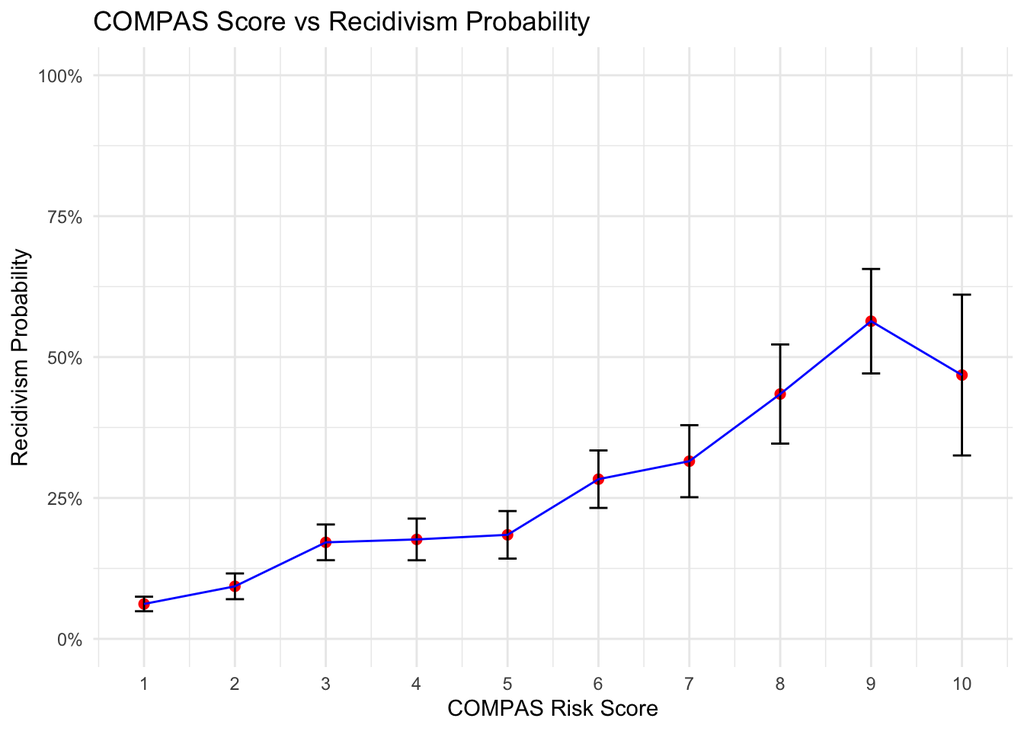

```r
ggplot(risk_analysis, aes(x = score, y = recid_prob)) +
  geom_point(size = 2, color = "red") +
  geom_errorbar(aes(ymin = ci_lower, ymax = ci_upper), width = 0.2) +
  geom_line(color = "blue") +
  scale_x_continuous(breaks = 1:10) +
  scale_y_continuous(limits = c(0, 1), labels = scales::percent) +
  labs(
    title = "COMPAS Score vs Recidivism Probability",
    x = "COMPAS Risk Score",
    y = "Recidivism Probability"
  ) +
  theme_minimal()
```

## c. Risk Score and Probability (by race)

Repeat the analysis, but this time do so for every race. Produce a set of plots (one per race) and comment on the patterns.

**Solution**

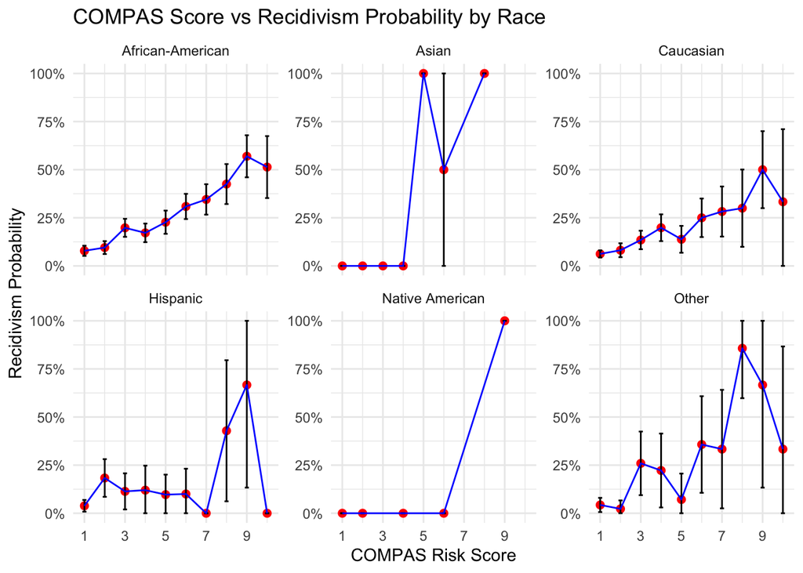

```r
risk_analysis_by_race <- risk %>%
  group_by(race, score) %>%
  summarise(
    n = n(),
    recid_prob = mean(outcome),
    se = sqrt(recid_prob * (1 - recid_prob) / n)
  ) %>%
  mutate(
    ci_lower = pmax(0, recid_prob - 1.96 * se),
    ci_upper = pmin(1, recid_prob + 1.96 * se)
  ) %>%
  ungroup()
ggplot(risk_analysis_by_race, aes(x = score, y = recid_prob)) +
  geom_point(size = 2, color = "red") +
  geom_errorbar(aes(ymin = ci_lower, ymax = ci_upper), width = 0.2) +
  geom_line(color = "blue") +
  facet_wrap(~ race, scales = "free_y") +
  scale_x_continuous(breaks = seq(1, 10, by = 2)) +
  scale_y_continuous(limits = c(0, 1), labels = scales::percent_format(accuracy = 1)) +
  labs(
    title = "COMPAS Score vs Recidivism Probability by Race",
    x = "COMPAS Risk Score",
    y =  "Recidivism Probability",
  ) +
  theme_minimal()
```

> first we can see that there isn’t much data for races other than African Americans and Caucasian beacuse these two races have the narrowest confidence intervals compared to other races. Second there is very inconsistent patterns for Asian, Hispanic, and Native Americans which suggests discrimination based on races.

## d. ROC Curves

Use the raw COMPAS risk scores to make a ROC curve for each race.

- Are the best discriminating models the ones you expected?
- Are the ROC curves helpful in evaluating the COMPAS risk score?

**Solution**

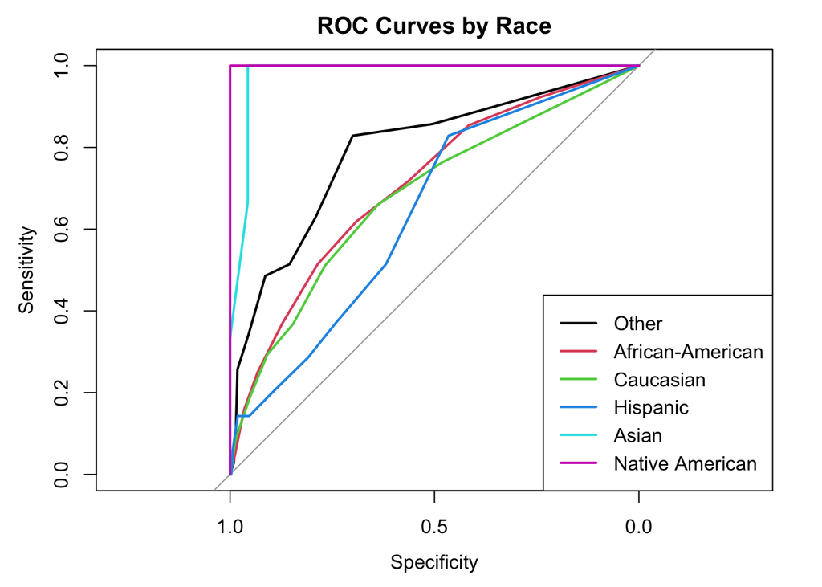

```r
library(pROC)
create_roc_curve <- function(data, race_group) {
  race_data <- data %>% filter(race == race_group)
  roc_obj <- roc(race_data$outcome, race_data$score)
  auc_value <- auc(roc_obj)

  list(roc = roc_obj, auc = auc_value)
}

races <- unique(risk$race)
roc_results <- map(races, ~create_roc_curve(risk, .))
names(roc_results) <- races

plot(roc_results[[1]]$roc, main="ROC Curves by Race", col=1)
for (i in 2:length(roc_results)) {
  plot(roc_results[[i]]$roc, add=TRUE, col=i)
}
legend("bottomright", legend=races, col=1:length(races), lwd=2)
```

# Problem 2: Support Vector Machines (SVM)

Focus on Problem 1, we won’t have an SVM problem this week.